# Netflix Trends

## Load and Explore Data

This section loads the dataset derived from https://www.kaggle.com/datasets/shivamb/netflix-shows and checks the basic structure, cleaning up the data to be more useful by doing the following:

- Removing duplicate rows
- Removing rows with empty columns
- Converting the date added to a DateTime object for better filtering
- Renaming listed_in to genre
- Splitting countries, directors, casts and genres into lists for better filtering
- Cleaning the genre list to not have movies or TV shows in the name
- Cleaning the genre list to categorize "Anime Features" and "Anime Series" as just "Anime"
- Dropping the date added column

```python
import pandas as pd
df = pd.read_csv("../data/netflix_titles.csv")

import matplotlib.pyplot as plt
import seaborn as sns

# Optional: make charts look nicer
sns.set(style="whitegrid")
%matplotlib inline

df_cleaned = df.drop_duplicates()
print(f"Number of rows after removing duplicates: {df_cleaned.shape[0]}")

# Remove rows with any NaN values.
df_cleaned = df_cleaned.dropna()
print(f"Number of rows after removing NaN values: {df_cleaned.shape[0]}")

# Convert "date_added" to a datetime object.
df_cleaned['date_added'] = pd.to_datetime(df_cleaned['date_added'], errors='coerce')

# Rename "listed_in" to "genre"
df_cleaned = df_cleaned.rename(columns={'listed_in': 'genre'})
print("Renamed 'listed_in' column to 'genre'.")

# Split the country column into lists of countries.
df_cleaned['country'] = df_cleaned['country'].str.split(', ')

def clean_country_list(country_list):
    cleaned = []
    for c in country_list:
        c = c.strip()          # remove spaces
        c = c.rstrip(",")      # remove trailing comma
        if c != "":            # ignore empty entries
            cleaned.append(c)
    return cleaned

df_cleaned['country'] = df_cleaned['country'].apply(clean_country_list)

# Split the director columns into lists.
df_cleaned['director'] = df_cleaned['director'].str.split(', ')

# Split the cast column into lists of actors.
df_cleaned['cast'] = df_cleaned['cast'].str.split(', ')

# Split the genre column into lists of genres.
df_cleaned['genre'] = df_cleaned['genre'].str.split(', ')

def clean_genre_list(genre_list):
    cleaned = []
    for g in genre_list:
        g = g.replace(" Movies", "").replace(" TV Shows", "").replace("TV ", "").replace("Anime Features", "Anime").replace("Anime Series", "Anime")
        cleaned.append(g)
    return cleaned

df_cleaned['genre'] = df_cleaned['genre'].apply(clean_genre_list)

# Drop the "date_added" column.
df_cleaned = df_cleaned.drop(columns=['date_added'])
print("Dropped 'date_added' column.")
```

```
Number of rows after removing duplicates: 8807
Number of rows after removing NaN values: 5332
Renamed 'listed_in' column to 'genre'.
Dropped 'date_added' column.
```

## Data Exploration

Exploring the data to retrieve the total number of movies and TV shows, the number of films released each year from 2000 to 2020, the top movie genre per country, the top five shows with the most seasons, the top 5 most frequent directors, and the top 5 countries with the most movies.

```python
# Number of movies vs TV shows
type_counts = df_cleaned['type'].value_counts()
print("Counts of each type (Movie vs TV Show):")
for t, c in type_counts.items():
    print(f"{t}: {c}")
print()
```

```
Counts of each type (Movie vs TV Show):
Movie: 5185
TV Show: 147
```

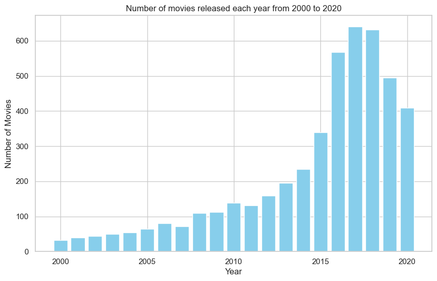

```python
# Number of movies released each year from 2000 to 2020
movies_per_year = (
    df_cleaned[(df_cleaned['type'] == 'Movie') & (df_cleaned['release_year'].between(2000, 2020))]
    .groupby('release_year')
    .size()
)
# print("Number of movies released each year from 2000 to 2020:")
# for t, c in movies_per_year.items():
#     print(f"{t}: {c}")
# print()

plt.figure(figsize=(10,6))
plt.bar(movies_per_year.index, movies_per_year.values, color='skyblue')
plt.title('Number of movies released each year from 2000 to 2020')
plt.xlabel('Year')
plt.ylabel('Number of Movies')
plt.xticks(rotation=0)
plt.show()
```

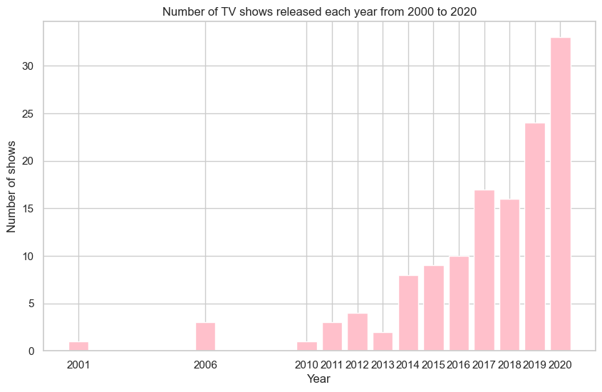

```python
# Number of shows released each year from 2000 to 2020
shows_per_year = (
    df_cleaned[(df_cleaned['type'] == 'TV Show') & (df_cleaned['release_year'].between(2000, 2020))]
    .groupby('release_year')
    .size()
)
# print("Number of shows released each year from 2000 to 2020:")
# for t, c in shows_per_year.items():
#     print(f"{t}: {c}")
print()

# convert index to int for plotting/labels
x = shows_per_year.index.astype(int)
y = shows_per_year.values
plt.figure(figsize=(10,6))
plt.bar(shows_per_year.index, shows_per_year.values, color='pink')
plt.title('Number of TV shows released each year from 2000 to 2020')
plt.xlabel('Year')
plt.ylabel('Number of shows')
plt.xticks(x,x,rotation=0)
plt.show()
```

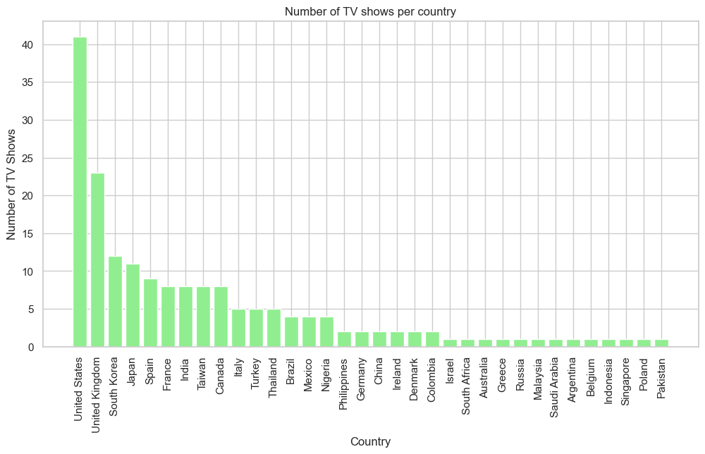

```python
# Number of TV shows per country
tv_shows_per_country = (
    df_cleaned[df_cleaned['type'] == 'TV Show']
    .explode('country')['country']
    .value_counts()
)

# print("Number of TV shows per country:")
# for t, c in tv_shows_per_country.items():
#     print(f"{t}: {c}")
# print()

plt.figure(figsize=(12,6))
plt.bar(tv_shows_per_country.index, tv_shows_per_country.values, color='lightgreen')
plt.title('Number of TV shows per country')
plt.xlabel('Country')
plt.ylabel('Number of TV Shows')
plt.xticks(rotation=90)
plt.show()
```

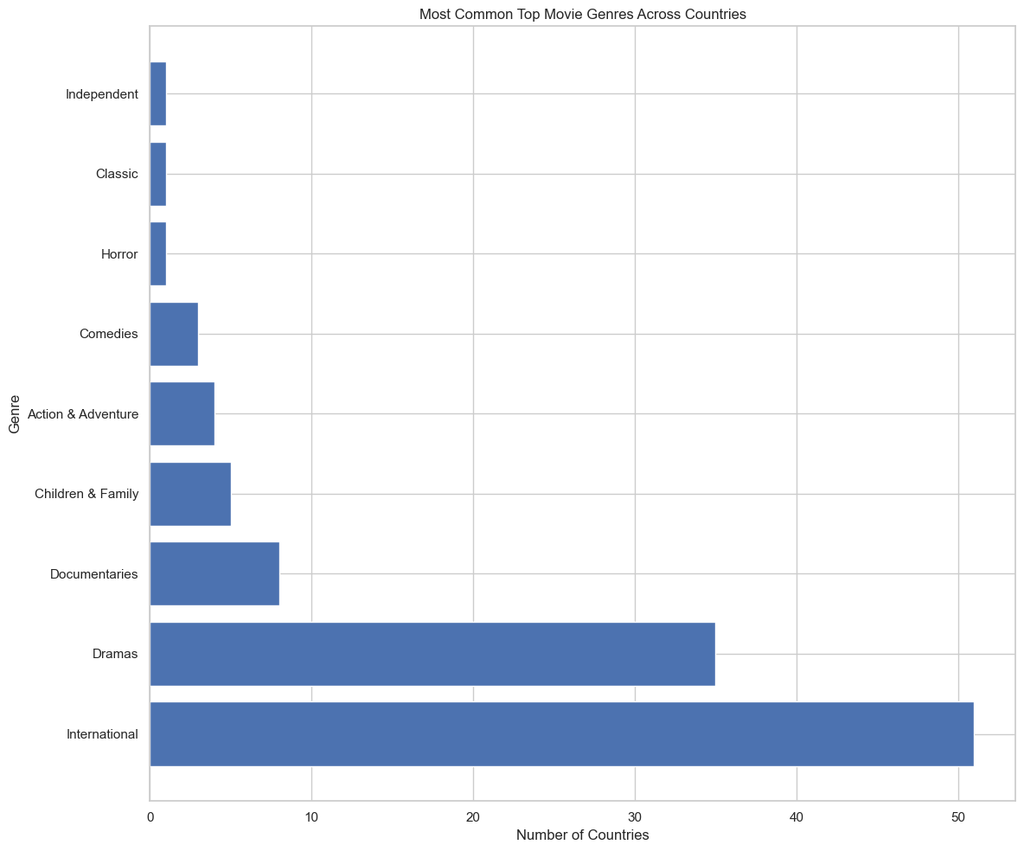

```python
# Top movie genres per country
movies = df_cleaned[df_cleaned['type'] == 'Movie'].explode('country').explode('genre')
top_genres = movies.groupby('country')['genre'].agg(lambda x: x.mode().iloc[0] if not x.mode().empty else 'Unknown')
# print("Top genre per country:")
# for t, c in top_genres.items():
#     print(f"{t}: {c}")
# print()

top_genres_df = top_genres.reset_index()
top_genres_df.columns = ['country', 'top_genre']

plt.figure(figsize=(12, 10))

# Count how many countries have each top genre
genre_counts = top_genres_df['top_genre'].value_counts()

plt.barh(genre_counts.index, genre_counts.values)
plt.title('Most Common Top Movie Genres Across Countries')
plt.xlabel('Number of Countries')
plt.ylabel('Genre')
plt.tight_layout()
plt.show()
```

[output not shown]

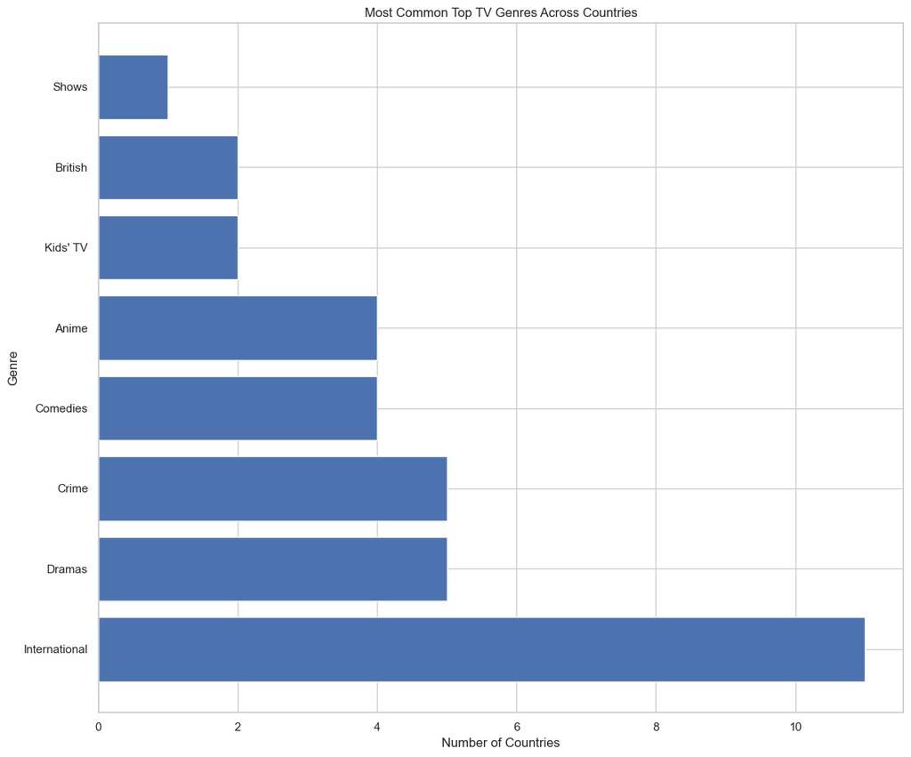

```python
# Top TV genres per country
tvshows = df_cleaned[df_cleaned['type'] == 'TV Show'].explode('country').explode('genre')
top_genres = tvshows.groupby('country')['genre'].agg(lambda x: x.mode().iloc[0] if not x.mode().empty else 'Unknown')
print("Top genre per country:")
# for t, c in top_genres.items():
#     print(f"{t}: {c}")
# print()

top_tv_genres = top_genres.reset_index()
top_tv_genres.columns = ['country', 'top_genre']
plt.figure(figsize=(12, 10))

# Count how many countries have each top genre
genre_counts = top_tv_genres['top_genre'].value_counts()

plt.barh(genre_counts.index, genre_counts.values)
plt.title('Most Common Top TV Genres Across Countries')
plt.xlabel('Number of Countries')
plt.ylabel('Genre')
plt.tight_layout()
plt.show()
```

```python
# Top 5 Shows with the most seasons
top_season_shows = df_cleaned[df_cleaned['type'] == 'TV Show'].sort_values(by='duration', ascending=False).head(5)
print("Top 5 TV Shows with the most seasons:")
print(top_season_shows[['title', 'duration']].to_string(index=False))
print()

# Average number of seasons for TV shows
avg_seasons = df_cleaned[df_cleaned['type'] == 'TV Show']['duration'].str.extract(r'(\d+)').astype(int).mean().iloc[0]
print("Average number of seasons for TV shows:")
print(f"{avg_seasons:.2f} seasons")
print()

# Top 5 most prominent directors
top_directors = (
    df_cleaned
    .explode('director')
    .groupby('director')
    .size()
    .sort_values(ascending=False)
    .head(5)
)
print("Top 5 most prominent directors:")
print(f"{'Director':30} {'Count':>5}")
print("-" * 40)

for director, count in top_directors.items():
    print(f"{director:30} {count:>5}")
print()

# Most popular genre for TV shows in the UK
uk_tv_shows = df_cleaned[
    (df_cleaned['type'] == 'TV Show') &
    (df_cleaned['country'].apply(lambda x: "United Kingdom" in x))
]
uk_tv_genres = uk_tv_shows.explode('genre')
most_common_genre = uk_tv_genres['genre'].mode().iloc[0]
print("Most popular genre for TV shows in the UK:", most_common_genre)
print()

# List of countries with "Anime" as their most common TV show genre
anime_countries = top_tv_genres[top_tv_genres['top_genre'] == 'Anime']['country'].tolist()
print("Countries with 'Anime' as their most common TV show genre:")
for country in anime_countries:
    print("-", country)
print()
```

```
Top 5 TV Shows with the most seasons:
                        title  duration
The Great British Baking Show 9 Seasons
                       Naruto 9 Seasons
             Call the Midwife 9 Seasons
                  Royal Pains 8 Seasons
                        Arrow 8 Seasons

Average number of seasons for TV shows:
1.90 seasons

Top 5 most prominent directors:
Director                       Count
----------------------------------------
Jan Suter                         21
Raúl Campos                       19
Marcus Raboy                      15
Jay Karas                         15
Cathy Garcia-Molina               13

Most popular genre for TV shows in the UK: British

Countries with 'Anime' as their most common TV show genre:
- Indonesia
- Japan
- Philippines
- Singapore
```

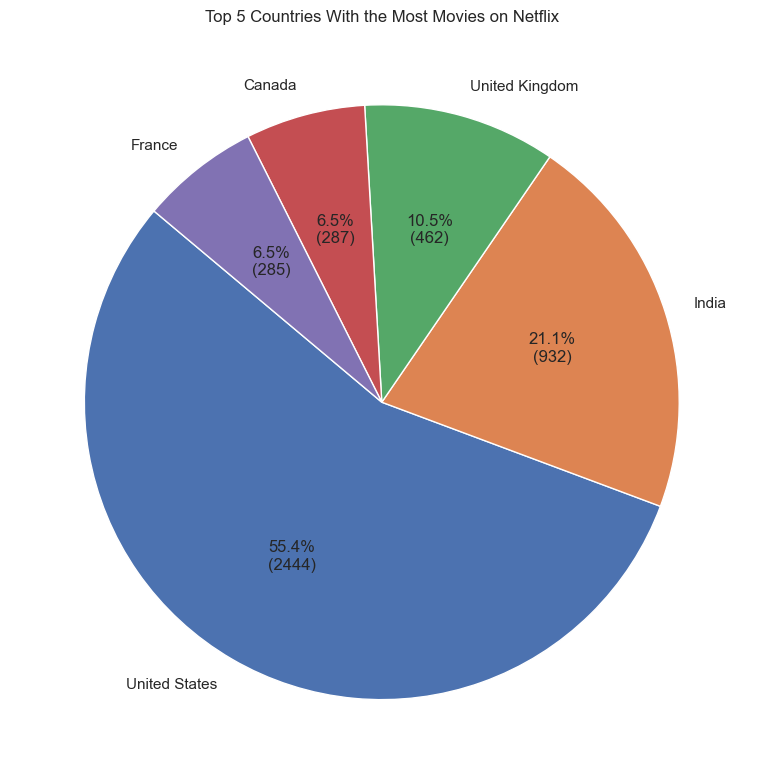

```python
# Find the top 5 countries with the most movies.
top_countries = (
    df_cleaned[df_cleaned['type'] == 'Movie']
    .explode('country')
    .groupby('country')
    .size()
    .sort_values(ascending=False)
    .head(5)
)

# print("Top 5 countries with the most movies:")
# print(f"{'Country':30} {'Count':>5}")
# print("-" * 40)
# for country, count in top_countries.items():
#     print(f"{country:30} {count:>5}")
# print()

labels = top_countries.index
sizes = top_countries.values

# Custom autopct function to show count + percent
def autopct_func(pct):
    total = sum(sizes)
    count = int(round(pct * total / 100.0))
    return f'{pct:.1f}%\n({count})'

plt.figure(figsize=(8, 8))
plt.pie(
    sizes,
    labels=labels,
    autopct=autopct_func,    # show percentages and counts
    startangle=140,       # rotate for nicer look
    wedgeprops={'linewidth': 1, 'edgecolor': 'white'}
)

plt.title('Top 5 Countries With the Most Movies on Netflix')
plt.tight_layout()
plt.show()
```

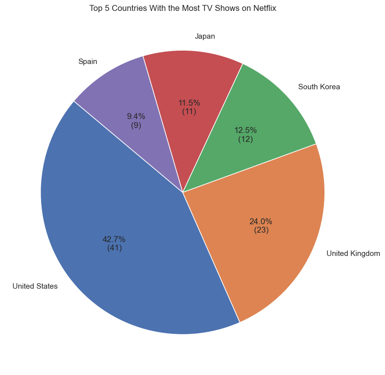

```python
# Find the top 5 countries with the most tv shows.
top_countries = (
    df_cleaned[df_cleaned['type'] == 'TV Show']
    .explode('country')
    .groupby('country')
    .size()
    .sort_values(ascending=False)
    .head(5)
)
# print("Top 5 countries with the most TV Shows:")
# print(f"{'Country':30} {'Count':>5}")
# print("-" * 40)
# for country, count in top_countries.items():
#     print(f"{country:30} {count:>5}")
# print()

labels = top_countries.index
sizes = top_countries.values

# Custom autopct function to show count + percent
def autopct_func(pct):
    total = sum(sizes)
    count = int(round(pct * total / 100.0))
    return f'{pct:.1f}%\n({count})'

plt.figure(figsize=(8, 8))
plt.pie(
    sizes,
    labels=labels,
    autopct=autopct_func,    # show percentages and counts
    startangle=140,       # rotate for nicer look
    wedgeprops={'linewidth': 1, 'edgecolor': 'white'}
)

plt.title('Top 5 Countries With the Most TV Shows on Netflix')
plt.tight_layout()
plt.show()
```

## Findings

**1. Geographic Content Distribution**

- The United States is the primary distributer for both TV shows and movies on Netflix with 2444 movies and 41 shows in the dataset, following with India at second place for film production with 932 movies and the United Kingdom at second place for TV shows with 23 shows. This data is consistent with the massive billion-dollar Hollywood and Bollywood industries which dominate other media industries globally.

**2. Genre Trends and Regional Preferences**

- The most common genre globally is “International” for both television and films, reflecting the worldwide user base that primarly consume media around their respective countries. This is further shown where the most common TV genre from Japan and South East Asia was “Anime” and “British” from the United Kindom. The genre category of “International” also suggests a need for more granular labeling within Netflix’s catalog metadata.

**4. Directors and Creators**

- Jan Suter has directed the most movies, a total of 21 films in the dataset.

## EXTRA: Highly specific data exploration

The following section is code that navigates the data to find specific information:

```python
# Titles of movies about CIA agents
cia_agent_movies = df_cleaned[
    (df_cleaned['type'] == 'Movie') &
    (df_cleaned['description'].str.contains("CIA", case=True, na=False))
]['title'].tolist()
print("Movies about CIA agents:")
for title in cia_agent_movies:
    print("-", title)
print()

# Titles of R rated Horror movies that are not from the US
r_rated_non_us_movies = df_cleaned[
    (df_cleaned['type'] == 'Movie') &
    (df_cleaned['rating'] == 'R') &
    (df_cleaned['genre'].apply(lambda g: "Horror" in g)) &
    (~df_cleaned['country'].apply(lambda x: "United States" in x))
]['title'].tolist()

print("R rated Horror movies not from the US:")
for title in r_rated_non_us_movies:
    print("-", title)
print()

# Titles of media starring "Anne Hathaway" released before 2010
anne_hathaway_pre_2010 = df_cleaned[
    (df_cleaned['cast'].apply(lambda x: "Anne Hathaway" in x)) &
    (df_cleaned['release_year'] < 2010)
]['title'].tolist()
print("Titles starring Anne Hathaway released before 2010:")
for title in anne_hathaway_pre_2010:
    print("-", title)
print()

# Average duration of movies released in 2020
avg_duration = df_cleaned[
    (df_cleaned['type'] == 'Movie') &
    (df_cleaned['release_year'] == 2010)
]['duration'].str.replace(" min", "").astype(int).mean()

print("Average duration of movies released in 2010:")
print(avg_duration, "minutes")
print()

#Longest running comedy TV show
comedy_tv = df_cleaned[
    (df_cleaned['type'] == 'TV Show') &
    (df_cleaned['genre'].apply(lambda g: "Comedies" in g))
].copy()

print(f"Number of comedy TV shows: {comedy_tv.shape[0]}")
print()

# Example: "3 Seasons" or "1 Season"
comedy_tv['num_seasons'] = comedy_tv['duration'].str.extract(r'(\d+)').astype(int)

# Find the longest running Comedy TV show
max_seasons = comedy_tv['num_seasons'].max()
longest_running = comedy_tv[comedy_tv['num_seasons'] == max_seasons]['title'].tolist()

print("Longest running Comedy TV show(s) with", max_seasons, "seasons:")
for title in longest_running:
    print("-", title)
print()

#Most recent Margot Robbie movie
most_recent_margot_movie = df_cleaned[
    (df_cleaned['type'] == 'Movie') &
    (df_cleaned['cast'].apply(lambda x: "Margot Robbie" in x))
].sort_values(by='release_year', ascending=False).head(1)
print("Most recent Margot Robbie movie:")
print(most_recent_margot_movie[['title', 'release_year']].to_string(index=False))
```

```
Movies about CIA agents:
- Safe House
- Clear and Present Danger
- Extraction
- The Interview
- The November Man
- American Ultra
- The Sum of All Fears
- Under Siege
- Mile 22
- The Take
- Kill the Messenger
- Battle Drone
- Act of Valor
- All the Devil's Men
- American Assassin
- Code Name: The Cleaner
- El último testigo
- Freeway: Crack in the System
- Incoming
- Kill Ratio
- Larceny
- Moonwalkers
- Patriot Games

R rated Horror movies not from the US:
- Ghosts of War
- 23:59
- Day of the Dead: Bloodline
- He Never Died
- Don't Knock Twice
- Friend Request
- The Lodgers

Titles starring Anne Hathaway released before 2010:
- Becoming Jane
- Get Smart
- Rachel Getting Married

Average duration of movies released in 2010:
106.66187050359713 minutes

Number of comedy TV shows: 30

Longest running Comedy TV show(s) with 8 seasons:
- Royal Pains

Most recent Margot Robbie movie:
       title  release_year
Peter Rabbit          2018
```